# The 171 countries study - revisiting the classic by Ancel Keys

## A short look onto the older data:

I would like to compare the following results with the original data from Keys. Unfortunately I was not able to find the raw data or online versions of the graphs (I know, that had been different times). Yet, I could at least find one from a preliminary study, reused by Yerushalmy and Hilleboe (1957, Stat J Med 57: 2343-54):

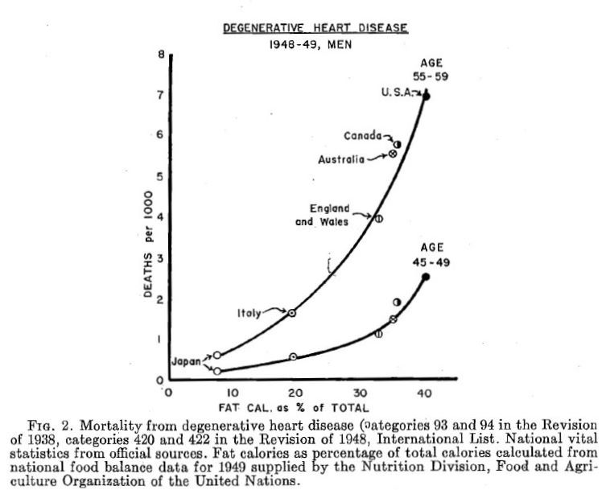

What an impressive correlation! Let’s see, what we find:

## New regression results:

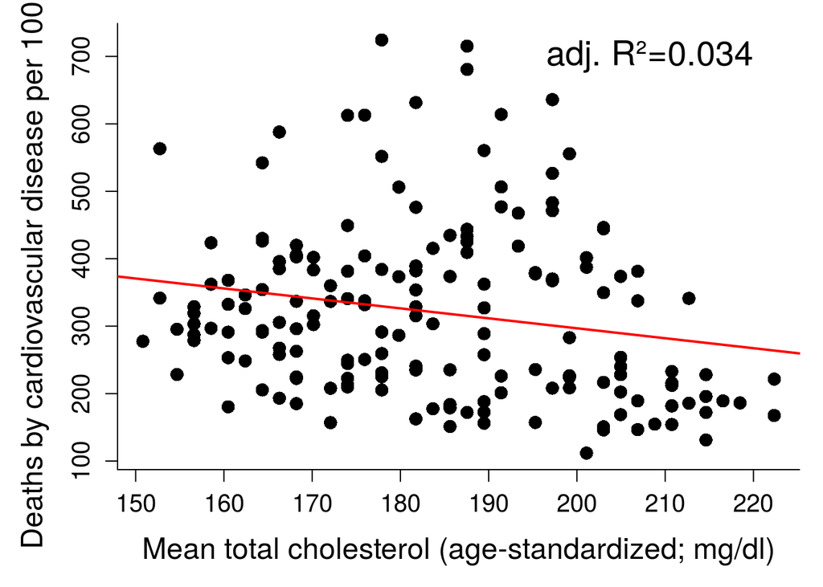

This looks like a pretty bad predictor for CVD deaths. The explained variance is close to zero. Funnily, the estimated slope is significant (P<0.01), and it is negative (-1.48)…

## One last note on statistics…

I thought it would be fun to extract the countries from the original curve shown earlier by Yerushalmy and Hilleboe and do the regression only with these:

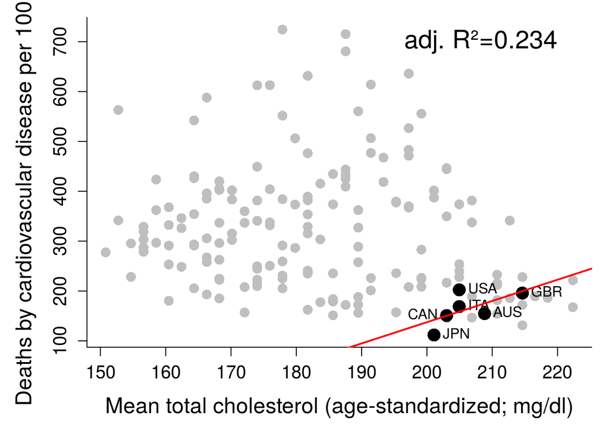

That is funny: of course we see by the ordering of the data points that these data do not resemble the original ones. Yet, just based on the low sample size, these six nations (which seem to suffer fairly weakly from CVD) would indicate a positive relationship, as suggested by Keys et al.; the explained variance is higher by accident. You should always avoid low sample size.